# STudy Group 7: Homework 3

Study Group 7: Thirat Wongwaisayawan, Lejla Kajevic, Francesco Nicolì, Zitong Hu, Rufei Wang, Siddharth Gulati

2022-09-12

# 1 Youth Risk Behavior Surveillance

Every two years, the Centers for Disease Control and Prevention conduct the [Youth Risk Behavior Surveillance System (YRBSS)](https://www.cdc.gov/healthyyouth/data/yrbs/index.htm) survey, where it takes data from high schoolers (9th through 12th grade), to analyze health patterns. You will work with a selected group of variables from a random sample of observations during one of the years the YRBSS was conducted.

## 1.1 Load the data

This data is part of the `openintro` textbook and we can load and inspect it. There are observations on 13 different variables, some categorical and some numerical. The meaning of each variable can be found by bringing up the help file:

?yrbss

```r
data(yrbss)
glimpse(yrbss)
```

```
## Rows: 13,583
## Columns: 13
## $ age                      <int> 14, 14, 15, 15, 15, 15, 15, 14, 15, 15, 15, 1…
## $ gender                   <chr> "female", "female", "female", "female", "fema…
## $ grade                    <chr> "9", "9", "9", "9", "9", "9", "9", "9", "9", …
## $ hispanic                 <chr> "not", "not", "hispanic", "not", "not", "not"…
## $ race                     <chr> "Black or African American", "Black or Africa…
## $ height                   <dbl> NA, NA, 1.73, 1.60, 1.50, 1.57, 1.65, 1.88, 1…
## $ weight                   <dbl> NA, NA, 84.4, 55.8, 46.7, 67.1, 131.5, 71.2, …
## $ helmet_12m               <chr> "never", "never", "never", "never", "did not …
## $ text_while_driving_30d   <chr> "0", NA, "30", "0", "did not drive", "did not…
## $ physically_active_7d     <int> 4, 2, 7, 0, 2, 1, 4, 4, 5, 0, 0, 0, 4, 7, 7, …
## $ hours_tv_per_school_day  <chr> "5+", "5+", "5+", "2", "3", "5+", "5+", "5+",…
## $ strength_training_7d     <int> 0, 0, 0, 0, 1, 0, 2, 0, 3, 0, 3, 0, 0, 7, 7, …
## $ school_night_hours_sleep <chr> "8", "6", "<5", "6", "9", "8", "9", "6", "<5"…
```

Before you carry on with your analysis, it’s is always a good idea to check with `skimr::skim()` to get a feel for missing values, summary statistics of numerical variables, and a very rough histogram.

## 1.2 Exploratory Data Analysis

```r
 #Summarising the variable
yrbss %>%
  skim(weight)
```

Data summary

| Name | Piped data |
| --- | --- |
| Number of rows | 13583 |
| Number of columns | 13 |
| _______________________ |  |
| Column type frequency: |  |
| numeric | 1 |
| ________________________ |  |
| Group variables | None |

**Variable type: numeric**

| skim_variable | n_missing | complete_rate | mean | sd | p0 | p25 | p50 | p75 | p100 | hist |
| --- | --- | --- | --- | --- | --- | --- | --- | --- | --- | --- |
| weight | 1004 | 0.93 | 67.9 | 16.9 | 29.9 | 56.2 | 64.4 | 76.2 | 181 | ▆▇▂▁▁ |

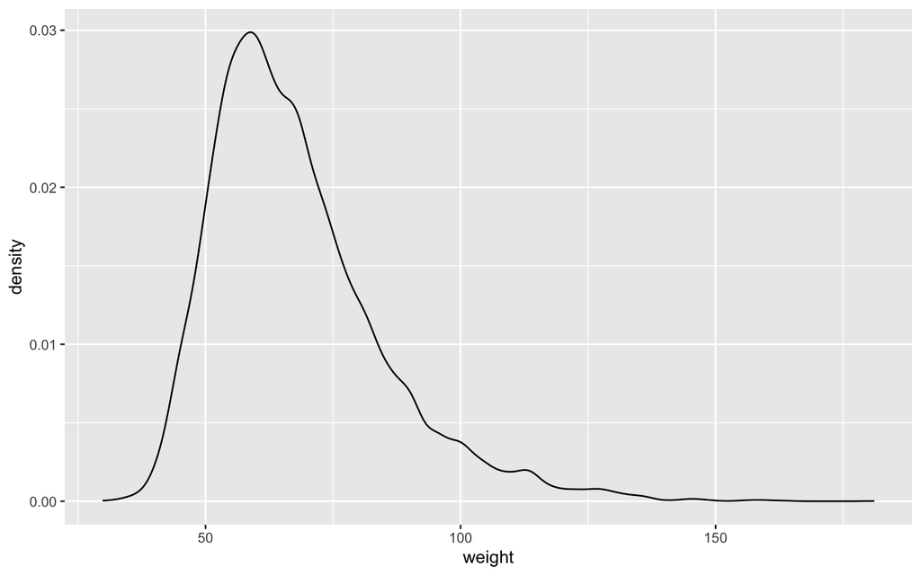

```r
#Plotting the variable
ggplot(yrbss, aes(x=weight, na.rm=TRUE)) + geom_density()
```

According to the summary statistics, there are 1004 missing weights data in the data set. We can also visualise the distribution of the variable “weight” and see how it is a heavily right-skewed distribution, with a most recurrent value of about 60 kg.

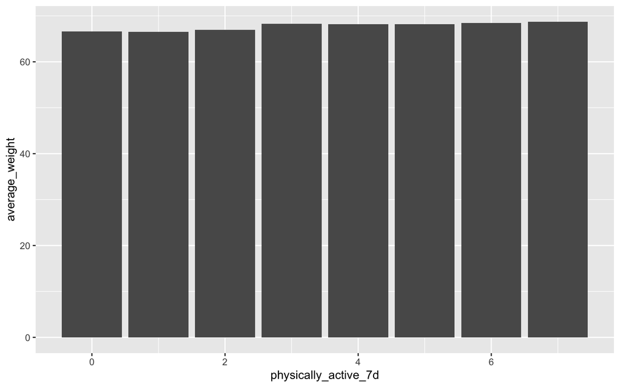

```r
correlation_summary <- yrbss %>%
  group_by(physically_active_7d) %>%
  summarise(average_weight = mean(weight, na.rm = TRUE))

ggplot(correlation_summary, aes(x=physically_active_7d, y=average_weight)) + geom_col()
```

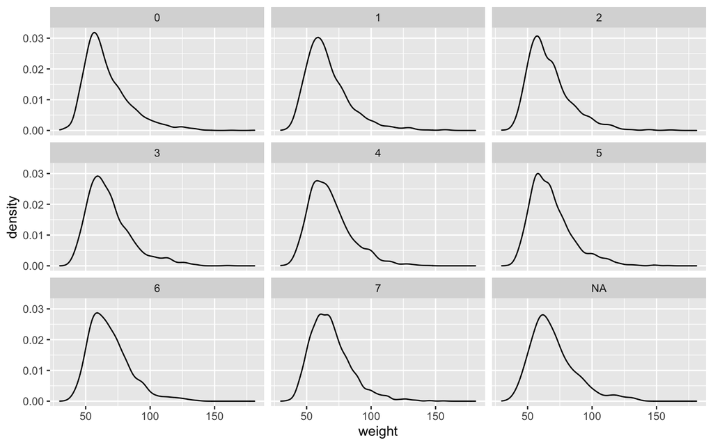

```r
ggplot(yrbss, aes(x=weight)) + geom_density() + facet_wrap(~physically_active_7d)
```

```r
#Building physical activity variable
yrbss_1 <- yrbss %>%
  mutate(physical_3plus=ifelse(physically_active_7d>=3,"yes","no"))

yrbss_1
```

```
## # A tibble: 13,583 × 14
##      age gender grade hispanic race        height weight helme…¹ text_…² physi…³
##    <int> <chr>  <chr> <chr>    <chr>        <dbl>  <dbl> <chr>   <chr>     <int>
##  1    14 female 9     not      Black or A…  NA      NA   never   0             4
##  2    14 female 9     not      Black or A…  NA      NA   never   <NA>          2
##  3    15 female 9     hispanic Native Haw…   1.73   84.4 never   30            7
##  4    15 female 9     not      Black or A…   1.6    55.8 never   0             0
##  5    15 female 9     not      Black or A…   1.5    46.7 did no… did no…       2
##  6    15 female 9     not      Black or A…   1.57   67.1 did no… did no…       1
##  7    15 female 9     not      Black or A…   1.65  132.  did no… <NA>          4
##  8    14 male   9     not      Black or A…   1.88   71.2 never   <NA>          4
##  9    15 male   9     not      Black or A…   1.75   63.5 never   <NA>          5
## 10    15 male   10    not      Black or A…   1.37   97.1 did no… <NA>          0
## # … with 13,573 more rows, 4 more variables: hours_tv_per_school_day <chr>,
## #   strength_training_7d <int>, school_night_hours_sleep <chr>,
## #   physical_3plus <chr>, and abbreviated variable names ¹helmet_12m,
## #   ²text_while_driving_30d, ³physically_active_7d
```

```r
#Calculating the percentage using count()
yrbss_1 %>%
  count(physical_3plus, sort=TRUE) %>%
  mutate(Percentage=n/sum(n))
```

```
## # A tibble: 3 × 3
##   physical_3plus     n Percentage
##   <chr>          <int>      <dbl>
## 1 yes             8906     0.656
## 2 no              4404     0.324
## 3 <NA>             273     0.0201
```

```r
#Calculating the percentage using group_by() and summarise()
 yrbss_1 %>%
  group_by(physical_3plus) %>%
  summarise(count=n()) %>%
  mutate(Percentage=count/sum(count))
```

```
## # A tibble: 3 × 3
##   physical_3plus count Percentage
##   <chr>          <int>      <dbl>
## 1 no              4404     0.324
## 2 yes             8906     0.656
## 3 <NA>             273     0.0201
```

We included the “Not Available” values since those are still part of the sample but we are just not sure about the “physical activity” of those kids. Hence, excluding them would have led to deceptive proportions for both the kids exercising at least three times a week and those who exercise less.

```r
Proportion_formula_ci <- yrbss_1 %>%
  select(physical_3plus) %>%
  count(physical_3plus) %>%
  summarise(Proportion=n/sum(n),
            t_critical=qt(0.975,n-1),
            se_proportion=sqrt((Proportion*(1-Proportion)/n)),
            margin_of_error=t_critical*se_proportion,
            Lower_limit=Proportion-margin_of_error,
            Upper_limit=Proportion+margin_of_error)

Proportion_formula_ci
```

```
## # A tibble: 3 × 6
##   Proportion t_critical se_proportion margin_of_error Lower_limit Upper_limit
##        <dbl>      <dbl>         <dbl>           <dbl>       <dbl>       <dbl>
## 1     0.324        1.96       0.00705         0.0138      0.310        0.338
## 2     0.656        1.96       0.00503         0.00987     0.646        0.666
## 3     0.0201       1.97       0.00849         0.0167      0.00338      0.0368
```

Can you provide a 95% confidence interval for the population proportion of high schools that are *NOT* active 3 or more days per week?

Make a boxplot of `physical_3plus` vs. `weight`. Is there a relationship between these two variables? What did you expect and why?

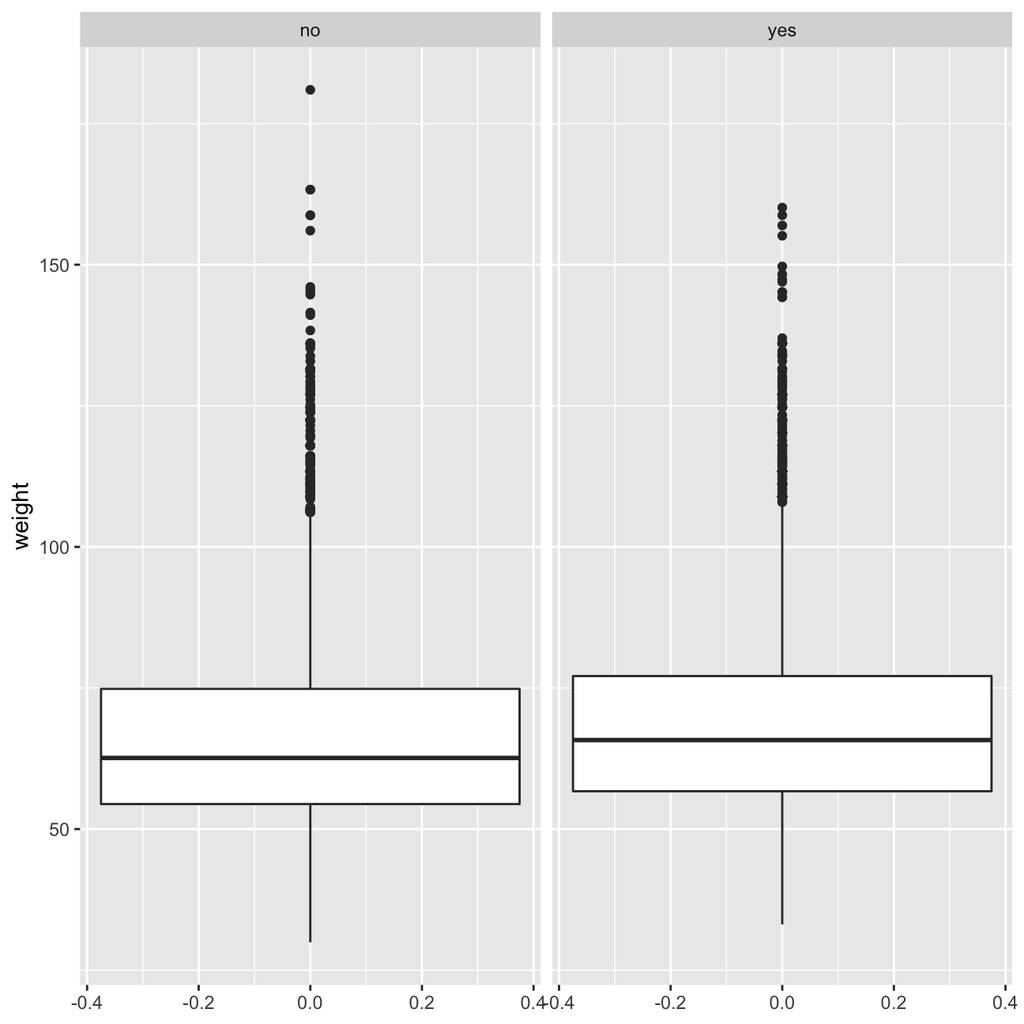

```r
Mutated_yrbss <- yrbss_1 %>%
  filter(physical_3plus == "yes"|physical_3plus=="no")

#Build the plot
ggplot(Mutated_yrbss, aes(y=weight)) + geom_boxplot() + facet_wrap(~physical_3plus)
```

At a younger age, it is logical to think that more physical exercise would lead to a lower weight, since it is unlikely that a kid gains weight and muscles through physical activity. Hence, the predominant effect of exercising would a decreasing fat and, consequently, a lower weight. Given the two boxplots, though, we can see how the median weight for the kids exercising three times a week or more is actually higher than the one for those who exercise less. The two distributions are still both right-skewed but the skeweness is more pronounced for those who exercise less. This results in a higher median, even though the difference is minimal.

## 1.3 Confidence Interval

Boxplots show how the medians of the two distributions compare, but we can also compare the means of the distributions using either a confidence interval or a hypothesis test. Note that when we calculate the mean, SD, etc. weight in these groups using the mean function, we must ignore any missing values by setting the `na.rm = TRUE`.

```r
Mutated_yrbss <- yrbss_1 %>%
  group_by(physical_3plus) %>%
  summarise(Average_weight=mean(weight, na.rm=TRUE),
            Standard_Deviation=sd(weight, na.rm=TRUE),
            Sample_size=n(),
            Standard_error=(Standard_Deviation/sqrt(Sample_size)),
            t_critical=qt(0.975,Sample_size-1),
            Lower_limit=(Average_weight-t_critical*Standard_error),
            Upper_limit=(Average_weight+t_critical*Standard_error)) %>%
  filter(!is.na(physical_3plus))

Mutated_yrbss
```

```
## # A tibble: 2 × 8
##   physical_3plus Average_weight Standa…¹ Sampl…² Stand…³ t_cri…⁴ Lower…⁵ Upper…⁶
##   <chr>                   <dbl>    <dbl>   <int>   <dbl>   <dbl>   <dbl>   <dbl>
## 1 no                       66.7     17.6    4404   0.266    1.96    66.2    67.2
## 2 yes                      68.4     16.5    8906   0.175    1.96    68.1    68.8
## # … with abbreviated variable names ¹Standard_Deviation, ²Sample_size,
## #   ³Standard_error, ⁴t_critical, ⁵Lower_limit, ⁶Upper_limit
```

There is an observed difference of about 1.77kg (68.44 - 66.67), and we notice that the two confidence intervals do not overlap. It seems that the difference is at least 95% statistically significant. Let us also conduct a hypothesis test.

## 1.4 Hypothesis test with formula

Write the null and alternative hypotheses for testing whether mean weights are different for those who exercise at least times a week and those who don’t.

```r
t.test(weight ~ physical_3plus, data = yrbss_1)
```

```
##
##  Welch Two Sample t-test
##
## data:  weight by physical_3plus
## t = -5, df = 7479, p-value = 9e-08
## alternative hypothesis: true difference in means between group no and group yes is not equal to 0
## 95 percent confidence interval:
##  -2.42 -1.12
## sample estimates:
##  mean in group no mean in group yes
##              66.7              68.4
```

Given that the Greek letter “delta” represents the difference between the two mean weights, we can represent the two hypotheses for the statistical test in this way:

$H_{0}: \delta = 0\\$$H_{1}: \delta \not= 0$

## 1.5 Hypothesis test with `infer`

Next, we will introduce a new function, `hypothesize`, that falls into the infer workflow. You will use this method for conducting hypothesis tests.

But first, we need to initialize the test, which we will save as `obs_diff`.

```r
obs_diff <- yrbss_1 %>%
  filter(!is.na(physical_3plus)) %>%
  specify(weight ~ physical_3plus) %>%
  calculate(stat = "diff in means", order = c("yes", "no"))

obs_diff
```

```
## Response: weight (numeric)
## Explanatory: physical_3plus (factor)
## # A tibble: 1 × 1
##    stat
##   <dbl>
## 1  1.77
```

Notice how you can use the functions specify and calculate again like you did for calculating confidence intervals. Here, though, the statistic you are searching for is the difference in means, with the order being yes - no != 0.

After you have initialized the test, you need to simulate the test on the null distribution, which we will save as null.

```r
null_dist <- yrbss_1 %>%
  filter(!is.na(physical_3plus)) %>%
  # specify variables
  specify(weight ~ physical_3plus) %>%

  # assume independence, i.e, there is no difference
  hypothesize(null = "independence") %>%

  # generate 1000 reps, of type "permute"
  generate(reps = 1000, type = "permute") %>%

  # calculate statistic of difference, namely "diff in means"
  calculate(stat = "diff in means", order = c("yes", "no"))

null_dist
```

```
## Response: weight (numeric)
## Explanatory: physical_3plus (factor)
## Null Hypothesis: independence
## # A tibble: 1,000 × 2
##    replicate    stat
##        <int>   <dbl>
##  1         1  0.121
##  2         2  0.317
##  3         3  0.153
##  4         4  0.441
##  5         5  0.300
##  6         6  0.0897
##  7         7  0.400
##  8         8 -0.0490
##  9         9  0.519
## 10        10 -0.660
## # … with 990 more rows
```

Here, `hypothesize` is used to set the null hypothesis as a test for independence, i.e., that there is no difference between the two population means. In one sample cases, the null argument can be set to *point* to test a hypothesis relative to a point estimate.

Also, note that the `type` argument within generate is set to permute, which is the argument when generating a null distribution for a hypothesis test.

We can visualize this null distribution with the following code:

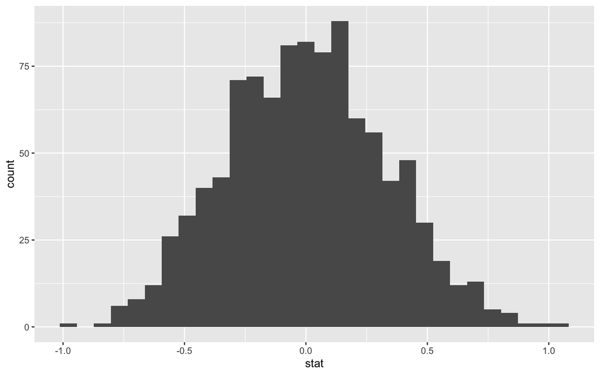

```r
ggplot(data = null_dist, aes(x = stat)) +
  geom_histogram()
```

Now that the test is initialized and the null distribution formed, we can visualise to see how many of these null permutations have a difference of at least `obs_stat` of 1.77?

We can also calculate the p-value for your hypothesis test using the function `infer::get_p_value()`.

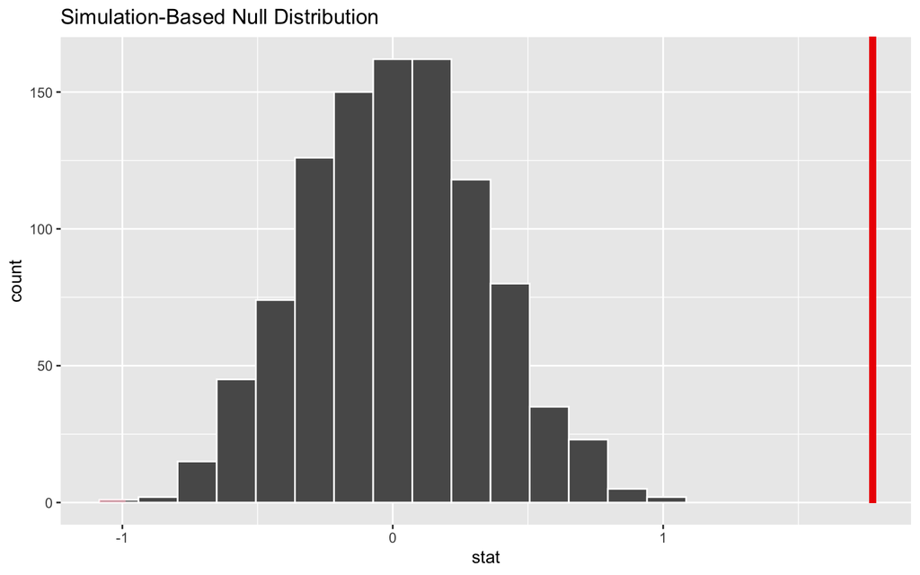

```r
null_dist %>% visualize() +
  shade_p_value(obs_stat = obs_diff, direction = "two-sided")
```

```r
null_dist %>%
  get_p_value(obs_stat = obs_diff, direction = "two_sided")
```

```
## # A tibble: 1 × 1
##   p_value
##     <dbl>
## 1       0
```

This the standard workflow for performing hypothesis tests.

# 2 IMDB ratings: Differences between directors

Recall the IMBD ratings data. I would like you to explore whether the mean IMDB rating for Steven Spielberg and Tim Burton are the same or not. I have already calculated the confidence intervals for the mean ratings of these two directors and as you can see they overlap.

Null Hypothesis: IMDB mean rating is the same for SS and TB. difference in m =0 Alternative hypothesis: difference in mean is not equal to 0. t-stat: difference between mean divided by standard error p-value

```r
movies <- read_csv(here::here("data", "movies.csv"))
#glimpse(movies)

movies_2 <- movies %>%
  group_by(director) %>%
  filter(director %in% c("Steven Spielberg","Tim Burton")) %>%
  summarise(rating,mean_rating = mean(rating), #find datapoints needed for t distribution.
         sd_rating = sd(rating),
         count=n(),
         t_critical =qt(0.975,count-1),
         se_rating = sd(rating)/sqrt(count),
         margin_of_error = t_critical*se_rating,
         rating_low = mean_rating - margin_of_error,
         rating_high = mean_rating +margin_of_error,
         highest_rating =max(rating),
         lowest_rating = min(rating))

#movies_mean<-count(movies, mean_rating)
#movies_mean
movies_2
```

```
## # A tibble: 39 × 12
## # Groups:   director [2]
##    director rating mean_…¹ sd_ra…² count t_cri…³ se_ra…⁴ margi…⁵ ratin…⁶ ratin…⁷
##    <chr>     <dbl>   <dbl>   <dbl> <int>   <dbl>   <dbl>   <dbl>   <dbl>   <dbl>
##  1 Steven …    7.9    7.57   0.695    23    2.07   0.145   0.301    7.27    7.87
##  2 Steven …    8.1    7.57   0.695    23    2.07   0.145   0.301    7.27    7.87
##  3 Steven …    6.2    7.57   0.695    23    2.07   0.145   0.301    7.27    7.87
##  4 Steven …    8      7.57   0.695    23    2.07   0.145   0.301    7.27    7.87
##  5 Steven …    8.5    7.57   0.695    23    2.07   0.145   0.301    7.27    7.87
##  6 Steven …    6.5    7.57   0.695    23    2.07   0.145   0.301    7.27    7.87
##  7 Steven …    6.5    7.57   0.695    23    2.07   0.145   0.301    7.27    7.87
##  8 Steven …    8.6    7.57   0.695    23    2.07   0.145   0.301    7.27    7.87
##  9 Steven …    8.3    7.57   0.695    23    2.07   0.145   0.301    7.27    7.87
## 10 Steven …    7.4    7.57   0.695    23    2.07   0.145   0.301    7.27    7.87
## # … with 29 more rows, 2 more variables: highest_rating <dbl>,
## #   lowest_rating <dbl>, and abbreviated variable names ¹mean_rating,
## #   ²sd_rating, ³t_critical, ⁴se_rating, ⁵margin_of_error, ⁶rating_low,
## #   ⁷rating_high
```

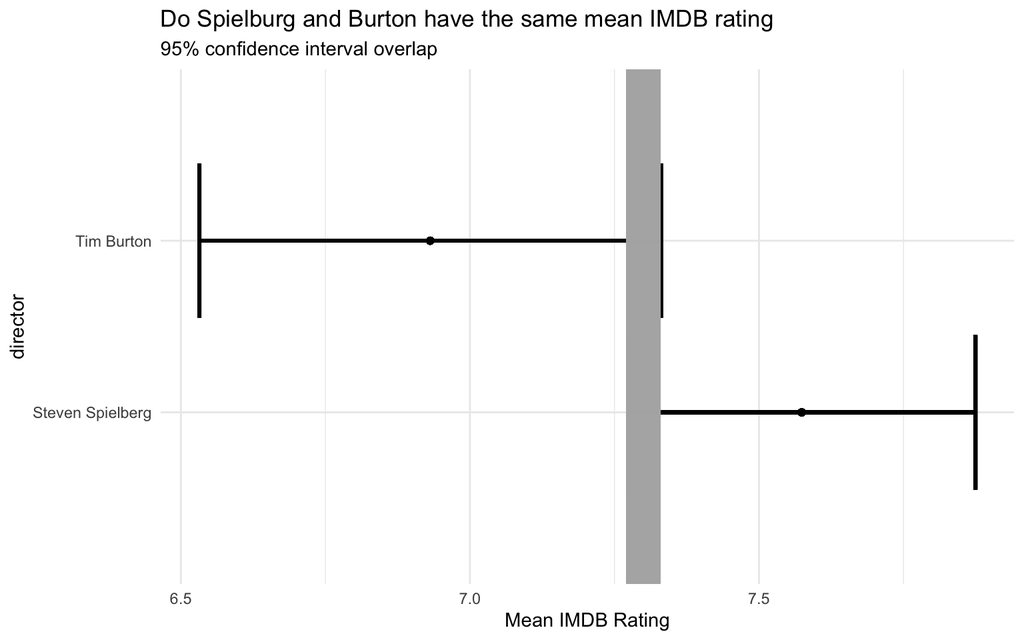

```r
  ggplot(movies_2, aes(x = mean_rating,y = director))+
  geom_point() +
  geom_errorbar(data = movies_2,aes(xmin = rating_low, xmax=rating_high,height=0.2), size = 1, height = 0.1)+
  labs(x = "Mean IMDB Rating",title = "Do Spielburg and Burton have the same mean IMDB rating",subtitle="95% confidence interval overlap")+
    geom_rect(aes(xmin=7.27, xmax= 7.33, ymin=0, ymax=3),
            fill = "grey70",
            alpha = 0.5)+
    theme_minimal()#+
```

```r
   # geom_text(aes(x= mean_rating, label = labels), vjust=0, nudge_y =0.05,overlap=FALSE)
  #geom_text(label=mean)
  #theme_bw()
```

## 2.1 Analysis

```r
t.test(rating~director, data = movies_2) #find t-stat, p-value
```

```
##
##  Welch Two Sample t-test
##
## data:  rating by director
## t = 3, df = 31, p-value = 0.01
## alternative hypothesis: true difference in means between group Steven Spielberg and group Tim Burton is not equal to 0
## 95 percent confidence interval:
##  0.16 1.13
## sample estimates:
## mean in group Steven Spielberg       mean in group Tim Burton
##                           7.57                           6.93
```

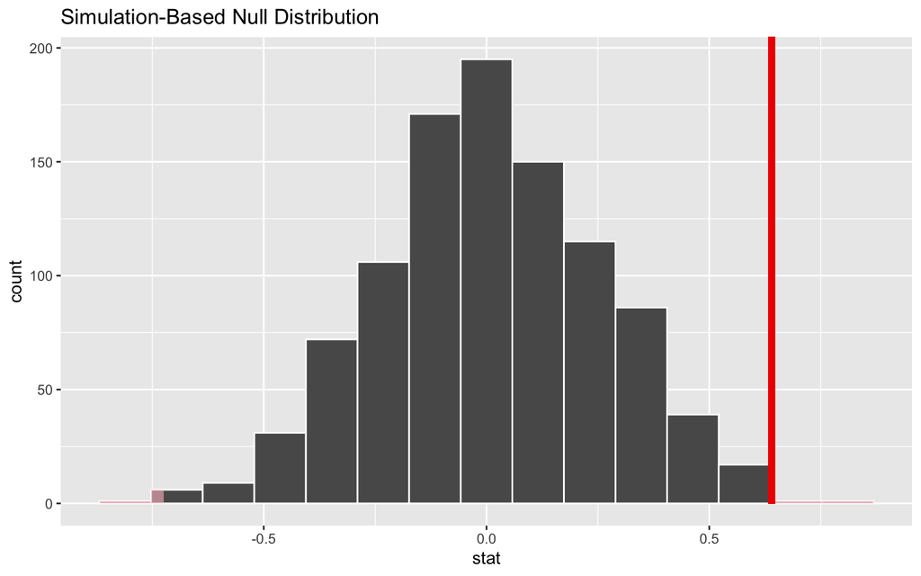

```r
#simulating a null world using infer()
set.seed(1234)
ratings_in_null_world <- movies_2 %>%
  specify(rating~director) %>% # we want to look at ratings of directors
  hypothesize(null = "independence") %>%  # hypothesize that the difference is 0
  generate(reps=1000, type="permute") %>% # create a bunch of simulated samples
  calculate(stat="diff in means", order = c("Steven Spielberg","Tim Burton")) # find difference in means of each sample.

#ratings_in_null_world visualize, with shaded p value
ratings_in_null_world %>% visualize() +
  shade_p_value(obs_stat = 0.64, direction = "two-sided")
```

```r
 # finding p-value of simulated distribution
p_value <- ratings_in_null_world%>%
  get_p_value(obs_stat = .64, direction = "two-sided")
p_value
```

```
## # A tibble: 1 × 1
##   p_value
##     <dbl>
## 1   0.004
```

With a p-value of 1%<5%, we can reject the null hypothesis that Spielburg and Burton have the same mean rating.  
You should use both the `t.test` command and the `infer` package to simulate from a null distribution, where you assume zero difference between the two.

By using the infer package, we can simulate from a null distribution and compute p-values (with get_p_value()). As seen from above, the p-value from the null distribution gives 0.4%<1%<5%. Thus, we can infer that the null hypothesis can be rejected.

We can conclude that the difference in mean ratings for the two directors is unlikely to be zero.

# 3 Omega Group plc- Pay Discrimination

At the last board meeting of Omega Group Plc., the headquarters of a large multinational company, the issue was raised that women were being discriminated in the company, in the sense that the salaries were not the same for male and female executives. A quick analysis of a sample of 50 employees (of which 24 men and 26 women) revealed that the average salary for men was about 8,700 higher than for women. This seemed like a considerable difference, so it was decided that a further analysis of the company salaries was warranted.

You are asked to carry out the analysis. The objective is to find out whether there is indeed a significant difference between the salaries of men and women, and whether the difference is due to discrimination or whether it is based on another, possibly valid, determining factor.

## 3.1 Loading the data

```r
omega <- read_csv(here::here("data", "omega.csv"))
glimpse(omega) # examine the data frame
```

```
## Rows: 50
## Columns: 3
## $ salary     <dbl> 81894, 69517, 68589, 74881, 65598, 76840, 78800, 70033, 635…
## $ gender     <chr> "male", "male", "male", "male", "male", "male", "male", "ma…
## $ experience <dbl> 16, 25, 15, 33, 16, 19, 32, 34, 1, 44, 7, 14, 33, 19, 24, 3…
```